# Coursera - Practical Machine Learning - Course Project

```r
library(ggplot2)
library(data.table)
library(caret)
library(corrplot)
```

# Import Data

```r
test_set <- read.csv("pml-testing.csv", na.strings = c("NA", "", "#DIV/0!"))
train_set_orig <- read.csv("pml-training.csv", na.strings = c("NA", "", "#DIV/0!"))
inTrain <- createDataPartition(y = train_set_orig$classe, p = 0.7, list = F)
train_set <- train_set_orig[inTrain,]
valid_set <- train_set_orig[-inTrain,]
remove(inTrain)
dim(train_set)
```

```
## [1] 13737   160
```

# Distribution of response

Review distribution of the response variable.

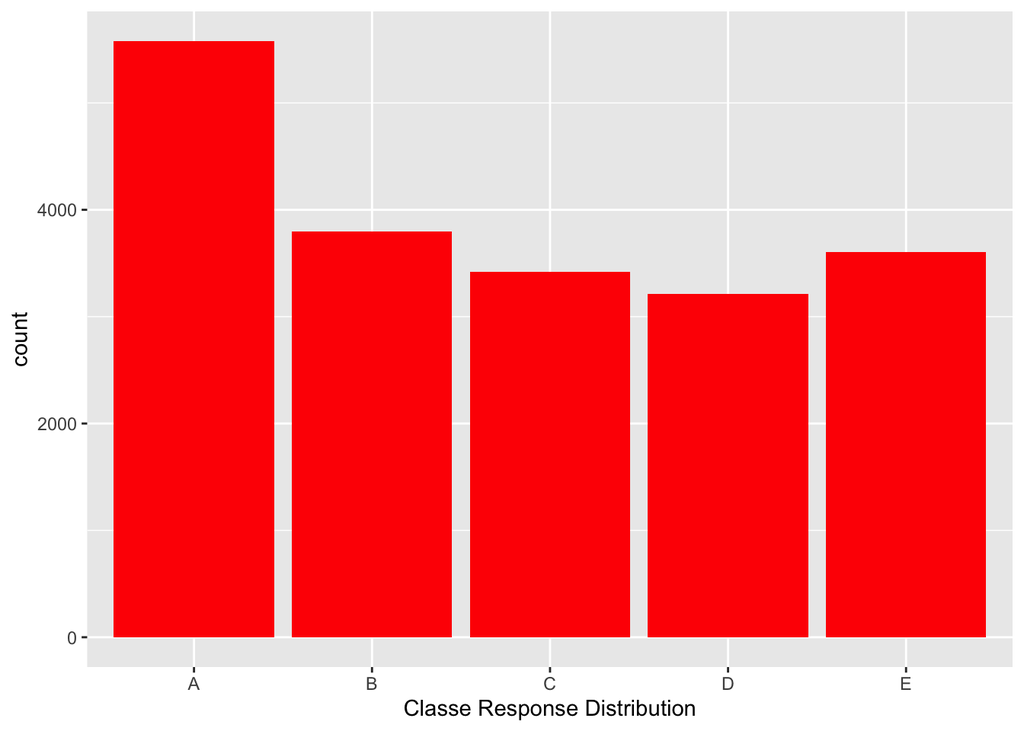

```r
ggplot(train_set_orig, aes(x=classe)) +
geom_bar(fill='red') +  labs(x='Classe Response Distribution')
```

# PreProcess

## Near Zero Variance Predictors

Identify and remove near-zero-variance predictors as they do not contribute to the identification of patterns in the data. For this purpose we use function caret::nearZeroVar().

```r
zeroVarIndices <- caret::nearZeroVar(train_set)
train_set <- train_set[, -zeroVarIndices]
dim(train_set)
```

```
## [1] 13737   129
```

## Remove Predictors with too many NAs (missing data)

```r
train_set <- train_set[,colMeans(is.na(train_set)) < .9]
dim(train_set)
```

```
## [1] 13737    59
```

## Reduce Collinearity

Collinearity is the situation where a pair of predictor variables have a substantial correlation with each other. In general, there are good reasons to avoid data with highly correlated predictors as it can result in highly unstable models and degraded predictive performance. ### Plot Correlations The darker areas in the correlation plot show variables which are correlated with each other.

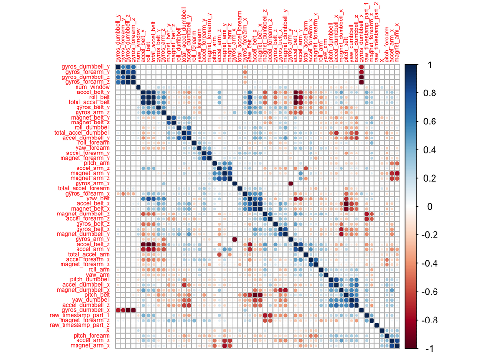

```r
trn_numeric <- train_set[,sapply(train_set, is.numeric)]
correlations <- cor(trn_numeric)
corrplot::corrplot(correlations, order = "hclust",tl.cex = 0.5)
```

### Filter pairwise correlations

```r
highCorr <- findCorrelation(correlations, cutoff = 0.75)
trn_numeric <- trn_numeric[, -highCorr]
dim(trn_numeric)
```

```
## [1] 13737    34
```

34 predictors remain after having removed correlated predictors. Review correlation plot again:

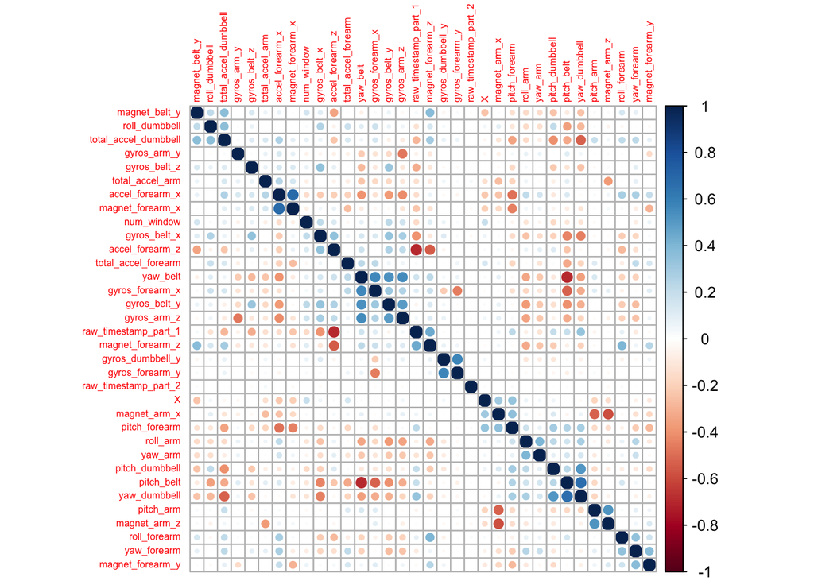

```r
correlations <- cor(trn_numeric)
corrplot::corrplot(correlations, order = "hclust",tl.cex = 0.5)
```

The darker areas have mostly disappeared as a result of having removed correlated predictors.

## Additional cleanup

```r
trn_numeric <- trn_numeric[, -c(1:3)]
```

# KNN

The model is trained with the KNN model. The standard bootstrap resampling will be applied with the standard setting of 25 repetitions. I preprocess the data in order to remove skewness, to center and to scale the data and to create principal components (on my 10 year old Macbook it takes about 5 minutes to run).

```r
# add back 'classe'
trn_numeric$classe <- train_set$classe
library(doParallel)
cl <- makePSOCKcluster(3)
registerDoParallel(cl)
# train model
knn_model <- caret::train(classe ~ .,
                          data = trn_numeric,
                          preProc = c("BoxCox", "center", "scale", "pca"),
                          method = "knn")
stopCluster(cl)
# print results
knn_model
```

```
## k-Nearest Neighbors
##
## 13737 samples
##    31 predictor
##     5 classes: 'A', 'B', 'C', 'D', 'E'
##
## Pre-processing: Box-Cox transformation (3), centered (31), scaled
##  (31), principal component signal extraction (31)
## Resampling: Bootstrapped (25 reps)
## Summary of sample sizes: 13737, 13737, 13737, 13737, 13737, 13737, ...
## Resampling results across tuning parameters:
##
##   k  Accuracy   Kappa
##   5  0.9352173  0.9180716
##   7  0.9239590  0.9038278
##   9  0.9139965  0.8912276
##
## Accuracy was used to select the optimal model using the largest value.
## The final value used for the model was k = 5.
```

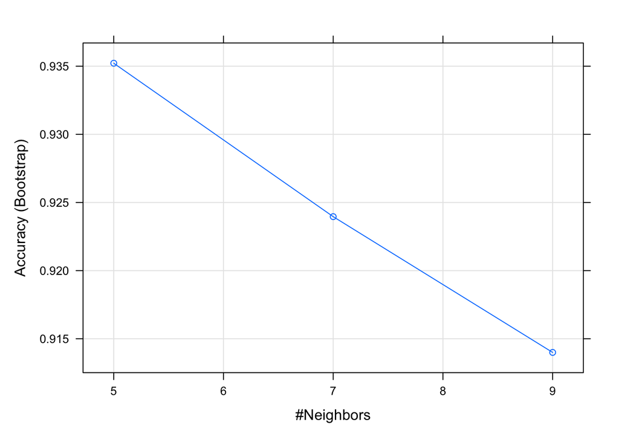

```r
plot(knn_model)
```

The plot of the KNN model shows that k = 5 provides the best result.

# Test Results on Validation Set

```r
valid_rf <- predict(knn_model, valid_set)
valid_conf_mtrx <- confusionMatrix(valid_rf, factor(valid_set$classe))
table(valid_set$classe)
```

```
##
##    A    B    C    D    E
## 1674 1139 1026  964 1082
```

```r
table(valid_rf)
```

```
## valid_rf
##    A    B    C    D    E
## 1681 1096 1096  947 1065
```

```r
valid_conf_mtrx$table
```

```
##           Reference
## Prediction    A    B    C    D    E
##          A 1634   34    6    3    4
##          B   13 1060   15    2    6
##          C   19   33  982   47   15
##          D    5    9   19  909    5
##          E    3    3    4    3 1052
```

# Predict on the Test Set

```r
predicted_classe <- predict(knn_model, test_set)
predicted_classe
```

```
##  [1] B A A A A C D B A A B C B A E E A B B B
## Levels: A B C D E
```